# Workshop 2: Genome Assembly

Your Name

2026-10-28

Notes for [Workshop 2](https://mb5370.bioinformatics.guide/workshop2.html). Run the commands for this workshop in the Terminal, from inside the folder named under each heading. Copy each command you run into a bash chunk.

## Redbean assembly

One of the fastest long read genome assemblers.

Commands run in `redbean/`.

```bash
cd ~/MB5370_Genomics/redbean
```

Collecting a small subset of data for the initial assembly. Only the first 3 files will be used.

```bash
cat /pvol/data/amtp4/*_[012].fastq > amtp4.fastq
```

Running the assembly

```bash
wtdbg2 -x ont -g 5m -t 4 -i amtp4.fastq -fo amtp4
wtpoa-cns -t 4 -i amtp4.ctg.lay.gz -fo amtp4.ctg.fa
```

Inspecting assembly statistics

```bash
assembly-stats amtp4.ctg.fa
```

Running redbean with higher coverage

```bash
cat /pvol/data/amtp4/*.fastq > amtp4_20x.fastq
wtdbg2 -x ont -g 5m -t 4 -i amtp4_20x.fastq -fo amtp4_20x
wtpoa-cns -t 4 -i amtp4_20x.ctg.lay.gz -fo amtp4_20x.ctg.fa
```

Inspecting higher coverage assembly statistics

```bash
assembly-stats amtp4_20x.ctg.fa
```

## Flye assembly

An older long read genome assemblers. It’s not as quick as redbean.

Commands run in `flye_genome/`.

```bash
pwd #Checking current directory
cd .. #Move up a directory
cd flye_genome
pwd #Confirming change in directory
```

Running Flye on both datasets

```bash
#Forming symbolic links to the same raw data used for redbean. Allows shortcut access to a different directory.
ln -s ../redbean/amtp4.fastq .
ln -s ../redbean/amtp4_20x.fastq .
```

Making a shellscript and saving it in the flye_genome folder.

```bash
#!/bin/bash
#SBATCH --time=60
#SBATCH --ntasks=4 --mem=10gb

echo "Starting flye in $(pwd) at $(date)"

flye --nano-raw amtp4.fastq --out-dir amtp4 --genome-size 5m --threads 4

echo "Finished flye in $(pwd) at $(date)"
```

Using the sbatch command to queue the slurm script so the HPC(High-Performance Computing) cluster to run hardware intensive tasks.

```bash
sbatch run_flye_small.sh
#This will say "submitted batch job XXX", where XXX is your slurm file number
```

You can check the status of the queue by running

```bash
squeue
#If your file number is missing from the JOBID column, then your file is done.
```

Additionally, to see the progress of the file being generated you can use the “tail” command.

```bash
tail -f slurm-XXX.out
#Displays the last 10 lines of the file and continues to display new lines as they are added to the file.
```

Outputs will be generated into folders and the final assembly will be called assembly.fasta.

Afterwards, you can check the contiguity and completeness of this assembly using assembly-stats

```bash
#Checking the smaller data set.
assembly-stats amtp4/assembly.fasta
#Checking the larger data set
assembly-stats amtp4_20x/assembly.fasta
```

## Assembly graphs with Bandage

Using Bandage, which is another app, we can inspect GFA files.

The outputs obtained from the small and large data set show solid colored lines. These continuous segments can be separated into independent graphs whereas others are connected via black lines (such as the top left graph of low coverage assembly).

**Low coverage assembly**

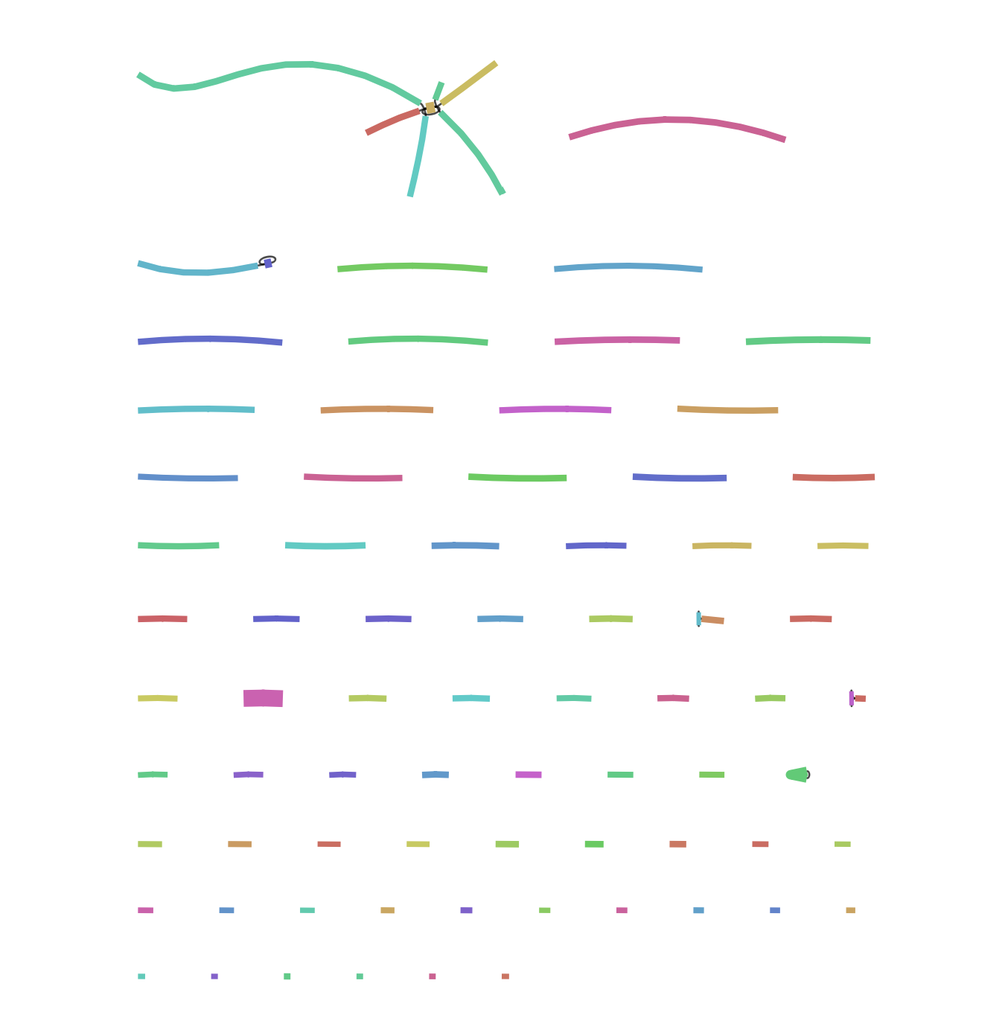

AMPT4

**High coverage assembly**

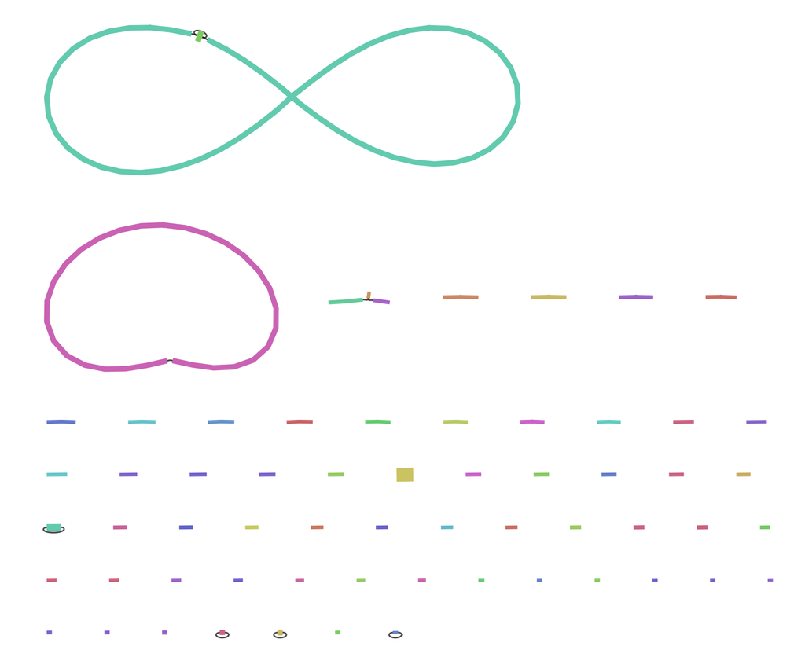

AMPT4_20x

Things to keep in mind:

- Biologically distinct entities will form separate graphs (eg. chromosomes or plasmids)
- Separated graphs can also occur if coverage is very low, leading to no reads and the inability to connect different parts of the genome together.
- Highly joined regions tend to occur because repeats creates ambiguities. Too many possible connections and the assembler has trouble selecting the correct path between them.

## Assembly quality with QUAST

Commands run in `quast/`.

**Checking assembly quality with QUAST.** First we need to change working directory to the QUAST folder.

```bash
pwd
cd ..
cd quast
pwd
```

Preparing the assembly data *Flye Assembly*

```bash
#We can use this commands to look at contig (continuous pieces of DNA) sizes in the flye assembly. It lists out all the contigs in the flye assembly and lists them from shortest to longest.
cat ../flye_genome/amtp4_20x/assembly.fasta | bioawk -c fastx '{print $name, length($seq)}' | sort -n -k2

#Column 1 = contig name
#Column 2 = congig length in base pairs
```

Note down the two largest contig numbers as our reference assembly only contains contigs for the two major Vibro chromosomes.

contig_10 = 3378257

contig_58 = 1775300

You can extract them from your assembly using the following command:

```bash
samtools faidx ../flye_genome/amtp4_20x/assembly.fasta contig_10 contig_58 > flye_asm/vibrio.fasta
```

*Redbean Assembly* We can repeat the steps above for redbean assembly

```bash
#Generating contig list
cat ../redbean/amtp4_20x.ctg.fa | bioawk -c fastx '{print $name, length($seq)}' | sort -n -k2
```

ctg1 = 3344006

ctg2 = 1764934

```bash
#Extracting using samtools
samtools faidx ../redbean/amtp4_20x.ctg.fa ctg1 ctg2 > redbean_asm/vibrio.fasta
```

Creating a symbolic link to access the original files from another folder.

```bash
ln -s ../flye_genome/amtp4_20x.fastq .
```

Creating a symbolic link to the reference assembly.

```bash
ln -s /pvol/data/amtp4/reference/vibrio .
```

Run the following quast command:

```bash
quast -o quast_vibrio redbean_asm/vibrio.fasta flye_asm/vibrio.fasta -L -t 4 --circos --glimmer -r vibrio/vibrio.fna --features  vibrio/vibrio.gff --nanopore amtp4_20x.fastq
```

Inspect the quast ouput by downloading it onto your laptop and unzipping the file. Look at the “report.html” and “circos/circos.png”

## Mystery repeat region

Commands run in `repeat/`.

```bash
#Changing working directory
pwd
cd ../repeat
pwd
```

Extract the repeat region sequence

1. Go to bandage and open the ampt4 assembly graph
2. Select the contig node where all the colored segments connect.
3. Use the output menu on the top bar and select the option to “copy selected path sequence to clipboard”.
4. Open a new text file and add a fasta header ‘>repeat_1’ on line 1.
5. Paste the path sequence on the second line and save the file into the repeat folder. Name the file “repeat.fasta”.

**Use prokka to annotate it**

```bash
#Run the following sequence
prokka --outdir prokka --prefix repeat repeat.fasta

#Examine the tsv file produced. What type of genomic features dominate this sequence?
cat prokka/repeat.tsv

#rRNA dominates this sequence due to the number of genes and total length.
```

**Investigating the genomic arrangements of repeats** Mapping the repeat sequence back to the genome itself using minimap2.

*Linking the data*

```bash
ln -s ../quast/vibrio/vibrio.fna .
```

*Running the minimap2*

```bash
minimap2 -x map-ont vibrio.fna repeat.fasta > repeat_vs_genome.paf
```

*Examining the output*

```bash
head  repeat_vs_genome.paf
#The results look complicated and the first 12 columns are only shown.
```

*Extracting the important columns*

```bash
#Since we want to find out if the arrangement of repeats is interspersed or tandem repeats, we need the columns specifying the start and end points on the target.
cat repeat_vs_genome.paf | grep '^repe' | awk -F '\t' '{print $6,$8,$9}' > repeat_locations.bed
```

After viewing the ‘.bed’ file produced, we can say that the repeats are interspersed. The repeats occur at different separate locations on the contig rather than being consecutively repeating.